# Introduction to DNA Methylation

Wednesday, October 29, 2014

## Background

- The term **epigenetics** is used to describe heritable features that control the functioning of genes within an individual cell, but do not constitute a physical change in the corresponding DNA sequence.
- Epidgenteic changes encompass an array of molecular modification to both DNA and chromatin. Epigenetic phenomena are mediated by various molecular mechanisms including,

  ```
  - histone modification
  - ATP-dependent chromatin-remodeling complexes
  - polycomb/trithorax protein complexes
  - small RNAs, including siRNA, microRNAs, and noncoding RNAs
  - DNA methylation
  ```

## Methylation

1. In chemistry, the addition of a methyl group to a molecule.
2. On a protein level, the addition of a methyl group or groups to the amino acid arginine or lysine in a protein.
3. On a DNA level, the addition of a methyl group to a cytosine residue to convert it to 5-methylcytosine.

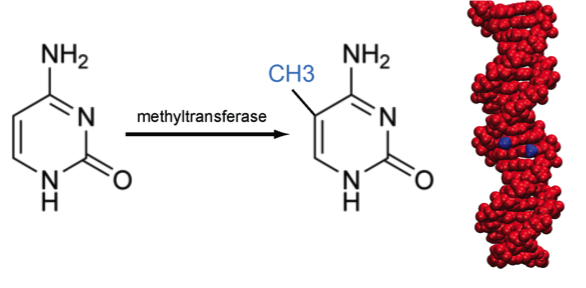

## DNA Methylaiton - CpG sites

- CpG sites are regions of DNA where a cytosine nucleotide occurs connected to a guanine nucleotide by a phosphodiester bonding
- CpG islands are found in the promoter region and first exons of many genes. They are mostly nonmethylated corresponding to the maintenance of an open chromatin structure and a potentially active state of transcription
- There are around 30,000 CpG islands in the human genome.

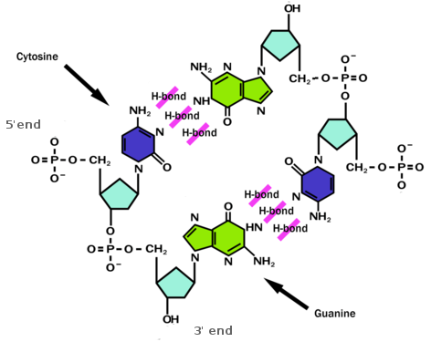

## DNA Methylation

- plays a vital role in numerous cellular processes, proper DNA methylation is essential for cell differentiation and embryonic development, and abnormal patterns of methylation have been linked to several human diseases.
- Methylation of CpG sites within the promoters of genes can lead to their silencing, a feature found in a number of human cancers (for example the silencing of tumor suppressor genes). In contrast, the hypomethylation of CpG sites has been associated with the over-expression of oncogenes within cancer cells.
- suppresses gene expression directly by inhibiting the binding of enzymes important in RNA synthesis at the promoter region, indirectly by recruiting methyl-CpG-binding proteins and their associated gene-suppressive chromatin-remodelling activites.
- responsive to, and alterable by enviromental signals; stage -of -life dependent.

## Method - Workflow

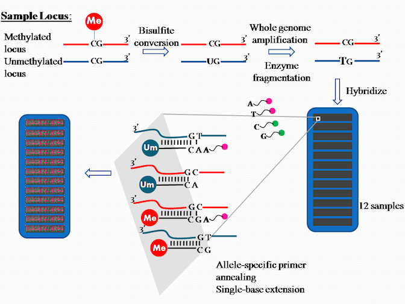

## Method - Measure

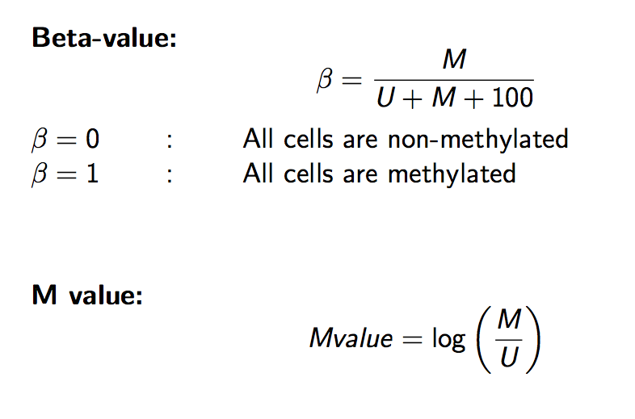

## Summary

- DNA methylation is vital to healthy cell growth and development and is linked to various processes such as genomic imprinting, carcinogenesis and the suppression of repetitive elements.
- Aberrant DNA methylation changes have been detected in several diseases, particularly cancer where genome-wide hypomethylation coincides with gene-specific hypermethylation
- DNA methylation patterns can be used to detect cancer at very early stages, to classify tumors as well as predict and monitor the response to antineoplastic treatment.
- As a stable nucleic acid-based modification with limited dynamic range that is technically easy to handle, DNA methylation is a promising biomarker for many applications.

## Conclusion

- Epigenetic modifications do not alter gene sequence, rather gene expression. Therefore, characterizing the expression profiles of epigenetically labile genes that are susceptible to environmental dysregulation will untimately identify epidgenetic biomarkers for disease and environmental exposure.
- The field of epigenetics of complex diseases is still in its infancy, but epigenetics might provide the missing link between the genetic susceptibility and the phenotype by mediating and modulating environmental influences differentially depending on the epigenotype of a disease susceptible locus.

## Reference

1. J Tost, et. al., DNA Methylation Methods and Protocols, Springers Publication (2009).
2. RL Jirtle, MK Skinner, Enviromental Epigenomics and Disease Susceptibility, Nat.Rev. Genet. Vol 8, 253-262 (Apr 2007)
3. S Dedeurwaerder, M Defrance, E Calonne, H DenisEvaluation of the Infinium Methylation 450K technology, Epigenomics, 3(6), 771–784 (2011)
4. PA Jones, P w Laird, Cancer epigenetics comes of age, Nat. Genet. 21 (2): 163-7. (Feb 1999).
5. VS Dalton, E Kolshus, DM McLoughlin, Epigenetics and depression: return of the repressed, Journal of Affectiv Disorders 155:1-12, (2014)